# Importando as bibliotecas

```python
import numpy as np
import pandas as pd
import matplotlib.pyplot as plt
import seaborn as sns
```

```python
plt.style.use('ggplot')
```

```python
# Estou utilizando o jupyter notebook extensions, talvez a formatação mude
```

# Carregando os dados

```python
data = pd.read_csv('salto_diurno.txt.forces',sep = '\t',skiprows = 4)
```

## Criando coluna do tempo

```python
#450 é a frequência da câmera que capturou a imagem
dt = 1/450.0
t = np.arange(0, len(data)*dt, dt)

#t = t.reshape(-1,1)
data['Tempo'] = t
```

## Selecionando os dados

```python
data = data[['FY5','Tempo']]
```

# Modelagem mecânica do problema

Um dos possiveís modelos de salto vertical de uma pessoa é uma particula com massa concentrada no centro de gravidade.

Dessa forma podemos usar a 2ª lei de Newton para através do conhecimento das forças agindo sobre o corpo determinar sua aceleração (integrando temos a velocidade e posição).

$$\vec F = m\vec a $$

Nesse experimento temos apenas a força do solo e a força da gravidade atuando sobre o corpo. Assim temos a força resultante dada por:

$$\vec F = m\vec g + \overrightarrow{GRF} $$

Por fim a equação que rege o movimento é:

$$ m\vec a = m\vec g + \overrightarrow{GRF} $$

# Gráficos dos dados experimentais

## força de reação do solo

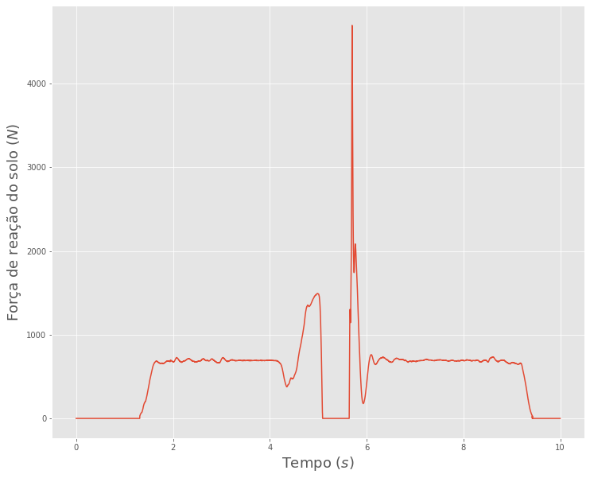

```python
fig = plt.figure(figsize = (12,10))
plt.plot(data.Tempo, data.FY5)
plt.ylabel(r'Força de reação do solo $(N)$', fontsize = 18)
plt.xlabel(r'Tempo $(s)$', fontsize = 18)
plt.show()
```

```python
g = 9.81
m = data[(data['Tempo'] >= 2) & (data['Tempo'] <= 3.5)]['FY5'].mean()/g
```

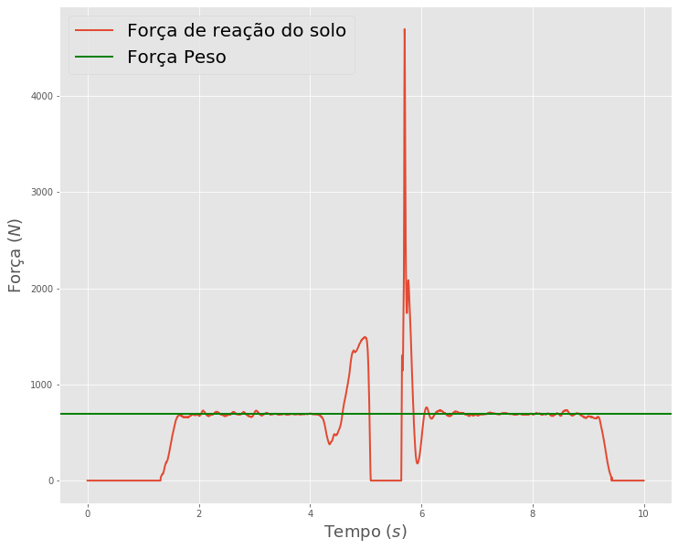

```python
fig = plt.figure(figsize = (12,10))

data['Peso'] = m*g

plt.plot(data.Tempo, data.FY5, lw = 2, label = 'Força de reação do solo')
plt.axhline(data.Peso[0], lw = 2, label = 'Força Peso', c = 'g')
plt.ylabel(r'Força $(N)$', fontsize = 18)
plt.xlabel(r'Tempo $(s)$', fontsize = 18)
plt.legend(fontsize = 20)
plt.show()
```

```python
data['Forca_total'] = data['FY5'] - data['Peso']
```

## Aceleração

Para encontrar a aceleração utilizamos a seguinte equação

$$ \vec F = m \vec a $$

A força resultante é dada por

$$\vec F = m \vec g + \overrightarrow{GRF} $$

assim temos

$$m \vec a = m \vec g +\overrightarrow{GRF}$$

isolando a aceleração

$$ \vec a = \frac{\overrightarrow{GRF}}{m} + \vec g $$

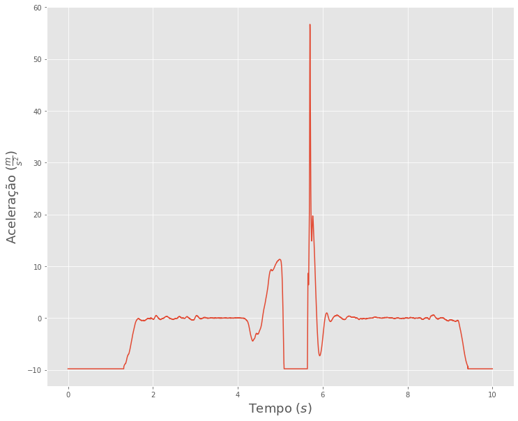

```python
data['Aceleracao'] = (data.FY5 - data.Peso)/m

fig = plt.figure(figsize = (12,10))
plt.plot(data.Tempo, data.Aceleracao)
plt.ylabel(r'Aceleração $(\frac{m}{s^2})$', fontsize = 18)
plt.xlabel(r'Tempo $(s)$', fontsize = 18)
plt.show()
```

## Velocidade

A velocidade pode ser encontrada integrando o vetor aceleração. Foi utilizado o método de Euler com velocidade inicial considerada 0.

```python
#Retira região no qual a pessoa entre e sai da balança
aux  = data[(data['Tempo'] >= 2.5) & (data['Tempo'] <= 7.5)]
aux  = aux.reset_index(drop=True)
dvdt = aux.Aceleracao.values
v    = np.zeros(len(aux))
```

```python
for i in np.arange(len(aux)-1):
    v[i+1] = v[i] + dt*dvdt[i]
aux['Velocidade'] = v
```

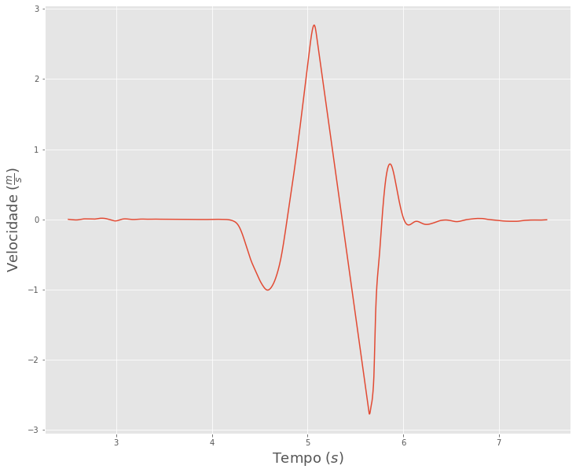

```python
fig = plt.figure(figsize = (12,10))

plt.plot(aux['Tempo'], v)
plt.ylabel(r'Velocidade $(\frac{m}{s})$', fontsize = 18)
plt.xlabel(r'Tempo $(s)$', fontsize = 18)
plt.show()
```

## Deslocamento vertical

Analogamente foi utilizado o método de Euler, considerando a posição inicial 0.

```python
dxdt = aux.Velocidade.values
x    = np.zeros(len(aux))
```

```python
for i in np.arange(len(aux)-1):
    x[i+1] = x[i] + dt*dxdt[i]
aux['Posicao'] = x
```

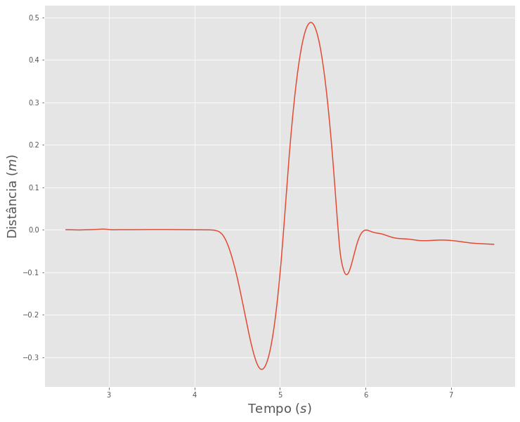

```python
fig = plt.figure(figsize = (12,10))

plt.plot(aux['Tempo'], x)
plt.ylabel(r'Distância $(m)$', fontsize = 18)
plt.xlabel(r'Tempo $(s)$', fontsize = 18)
plt.show()
```

## Potência mecânica do centro de gravidade

Potência é calculado como velocidade vezes força.

```python
aux['Potencia'] = aux['Velocidade']*aux['FY5']
```

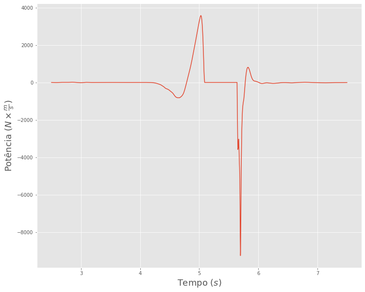

```python
fig = plt.figure(figsize = (12,10))

plt.plot(aux['Tempo'], aux['Potencia'])
plt.ylabel(r'Potência $(N\times\frac{m}{s})$', fontsize = 18)
plt.xlabel(r'Tempo $(s)$', fontsize = 18)
plt.show()
```

# Identificação das fases do salto

```python
#Achando o intervalo de voo
```

Em um salto vertical ocorre um agachamento, e então uma fase concêntrica, levando a impulsão e consequente fase de voo, seguido por uma fase de aterrissagem.

- Fase de equilibrio (**Parte azul**).
- Fase de agachamento (**Entre a parte azul e a parte verde**)
- Fase concêntrica (**Parte verde da imagem**)
- Fase de vôo (**Entre a parte verde e a parte preta**)
- Fase de aterrissagem (**Parte preta**)

A fase concêntrica e de agachamento que dão a impulsão para o salto, porém na fase de agachamento o centro de gravidade está se aproximando do solo enquanto na fase concêntrica ele se afasta. Na fase de voo o pé não toca o solo e aterrissagem é quando o sujeito volta a tocar o solo.

```python
#Intervalo aproximado de repouso
print(f'Instante aproximado de entrada: {2}\nInstante aproximado do começo do movimento: {4.2}\nTempo aproximado de salto: {(4.2 - 2)}')
```

```
Instante aproximado de entrada: 2
Instante aproximado do começo do movimento: 4.2
Tempo aproximado de salto: 2.2
```

```python
#Tempo de vôo:
#Os outros valores de 0 foram cortados...
t_inicio_voo = aux[aux['FY5'] == 0]['Tempo'].iloc[0]
t_final_voo =  aux[aux['FY5'] == 0]['Tempo'].iloc[-1:]
t_final_voo = t_final_voo.iloc[0]
print(f'Instante de salto: {t_inicio_voo},\nInstante de aterrissagem: {t_final_voo}\nTempo de salto: {t_final_voo - t_inicio_voo}')
```

```
Instante de salto: 5.091111111111111,
Instante de aterrissagem: 5.64
Tempo de salto: 0.5488888888888885
```

```python
descida_df = aux[aux[['Forca_total','Tempo']]['Tempo'] >= 4.2]

tempo_inicio_movimento = descida_df['Forca_total'].iloc[0]

acc = tempo_inicio_movimento

for grf, t in descida_df[['Forca_total','Tempo']].iloc[1:].values:
    acc += grf
    if(acc >= tempo_inicio_movimento):
        tempo_local_mais_baixo = t
        print(f'Intervalo do ponto mais baixo: {t}')
        break
```

```
Intervalo do ponto mais baixo: 4.7844444444444445
```

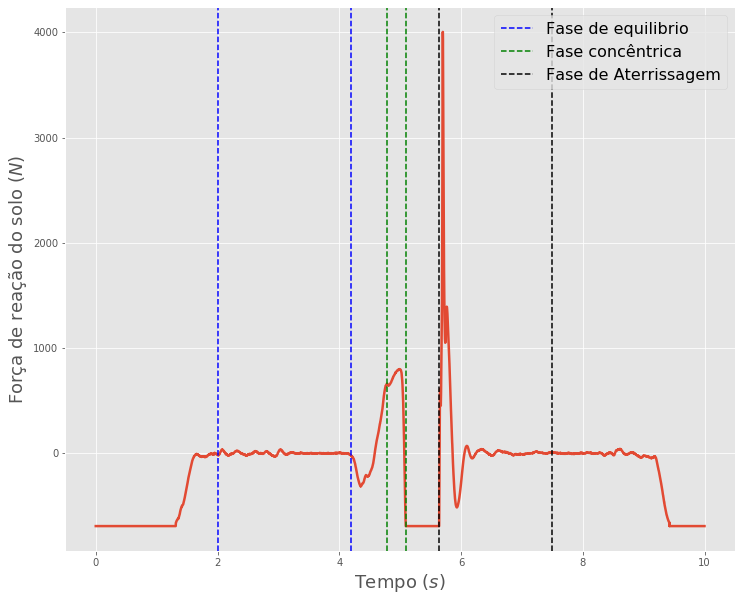

```python
fig = plt.figure(figsize = (12,10))
plt.plot(data.Tempo, data.Forca_total, lw = 2.5)

#Fase de repouso
plt.axvline(x=2, c = 'blue', ls ='--', label = 'Fase de equilibrio')
plt.axvline(x=4.2, c = 'blue', ls = '--')

#Fase concêntrica
plt.axvline(x=tempo_local_mais_baixo, c = 'green', ls ='--', label = 'Fase concêntrica')
plt.axvline(x=t_inicio_voo, c = 'green', ls ='--')

#Aterrissagem
plt.axvline(x=t_final_voo, c = 'black', ls ='--', label = 'Fase de Aterrissagem')
plt.axvline(x=aux['Tempo'].iloc[len(aux['Tempo'])-1], c = 'black', ls ='--')

plt.ylabel(r'Força de reação do solo $(N)$', fontsize = 18)
plt.xlabel(r'Tempo $(s)$', fontsize = 18)
plt.legend(fontsize= 16)
plt.show()
```

# Estimativa da altura do salto

## Usando o tempo de vôo

Para estimar o tempo de voo utilizamos a seguinte equação

$$h = h_0+v_0t+\frac{at^2}{2}$$

Sabemos que ao atingir a altura máxima a velocidade é igual a zero e a única força que o sujeito está submetido é a da gravidade. Também sabemos que o tempo de caída é metade do tempo de voo, sendo assim podemos substituir esses parâmetros na equação acima e isolar a altura máxima chegando na seguinte equação

$$h_{max} = \frac{gt_{vôo}^2}{8} $$

através dessa equação calculamos então a altura máxima em metros:

```python
altura = g*((t_final_voo - t_inicio_voo)/2)**2/2
altura
```

```
0.3694433888888884
```

## Variação da quantidade de movimento

Quando realizamos os gráficos ja calculamos a altura segundo a segundo através da variação da quantidade de movimento.

Logo para obter a altura máxima podemos encontrar o maior valor do vetor de altura (h) calculado anteriormente.

```python
aux['Posicao'].max()
```

```
0.4880827359629772
```

Usando torriceli ($V_f^2 = V_0^2 + 2a\Delta s$):

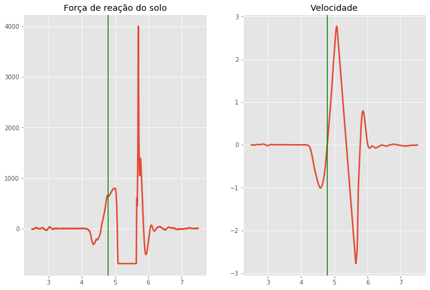

```python
fig, axs =plt.subplots(1,2,figsize = (12,8))
axs[0].plot(aux.Tempo, aux.Forca_total, lw = 2.5)
axs[0].set_title('Força de reação do solo')

axs[1].plot(aux.Tempo, aux.Velocidade, lw = 2.5)
axs[1].set_title('Velocidade')

axs[1].axvline(tempo_local_mais_baixo, c = 'g')
axs[0].axvline(tempo_local_mais_baixo, c = 'g')
plt.show()
```

```python
aux['Velocidade'].max()**2/(2*g)
```

```
0.39098020019078183
```

# Plotando os gráficos juntos

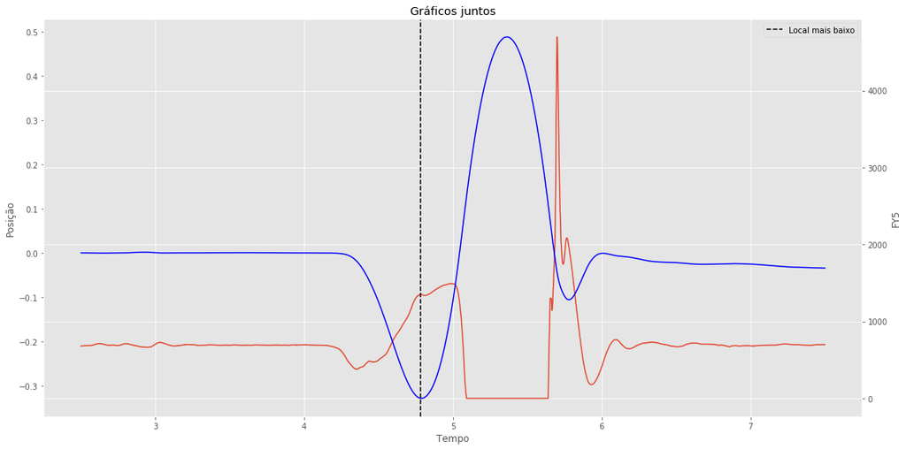

```python
#Não vou plotar o último grupo (U) por que o mesmo tem uma representação muito pequena
fig = plt.figure(figsize=(16,8))


plot = sns.lineplot(x="Tempo", y="FY5", data=aux)
plot.set_title('Gráficos juntos')

ax2 = plot.twinx()

# Switch
ax2.yaxis.tick_left()
plot.yaxis.tick_right()

# Also switch the labels over
plot.yaxis.set_label_position('right')
ax2.yaxis.set_label_position('left')

sns.lineplot(x="Tempo", y="Posicao", data=aux, ax = ax2, c = 'b')
ax2.set_ylabel('Posição')
plt.axvline(x=tempo_local_mais_baixo, c = 'black', ls ='--', label = 'Local mais baixo')

plt.legend()

# Need to turn the grid on ax2 off, otherwise the gridlines end up on top of the bars
ax2.grid(None)
plt.tight_layout()
plt.show()
```

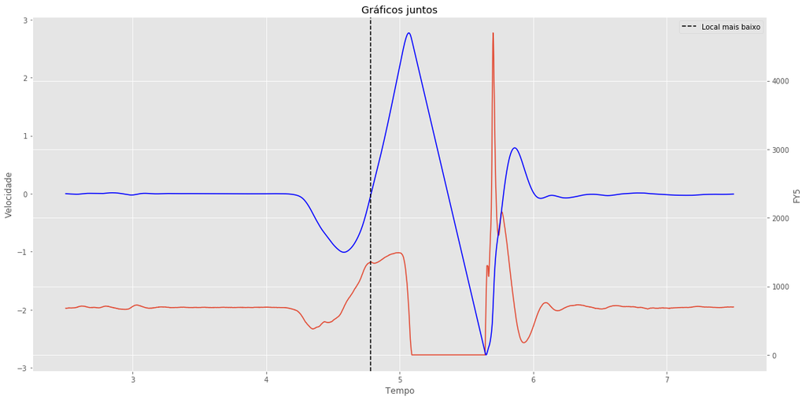

```python
#Não vou plotar o último grupo (U) por que o mesmo tem uma representação muito pequena
fig = plt.figure(figsize=(16,8))


plot = sns.lineplot(x="Tempo", y="FY5", data=aux)
plot.set_title('Gráficos juntos')

ax2 = plot.twinx()

# Switch
ax2.yaxis.tick_left()
plot.yaxis.tick_right()

# Also switch the labels over
plot.yaxis.set_label_position('right')
ax2.yaxis.set_label_position('left')

sns.lineplot(x="Tempo", y="Velocidade", data=aux, ax = ax2, c = 'b')
ax2.set_ylabel('Velocidade')
plt.axvline(x=tempo_local_mais_baixo, c = 'black', ls ='--', label = 'Local mais baixo')

plt.legend()

# Need to turn the grid on ax2 off, otherwise the gridlines end up on top of the bars
ax2.grid(None)
plt.tight_layout()
plt.show()
```

Nesse ponto percebemos que o ponto mais baixo é onde ele começa a produzir potência (começa a ficar positivo)

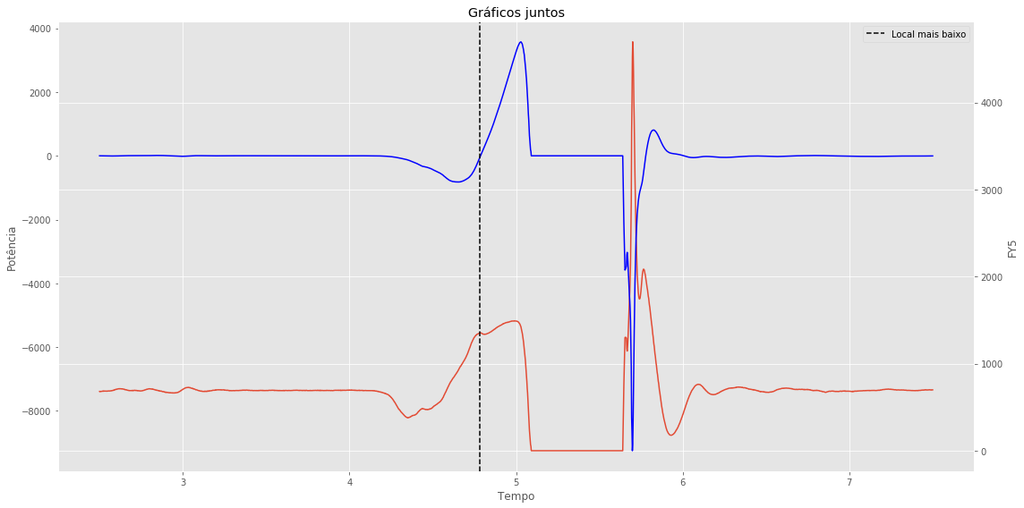

```python
#Não vou plotar o último grupo (U) por que o mesmo tem uma representação muito pequena
fig = plt.figure(figsize=(16,8))


plot = sns.lineplot(x="Tempo", y="FY5", data=aux)
plot.set_title('Gráficos juntos')

ax2 = plot.twinx()

# Switch
ax2.yaxis.tick_left()
plot.yaxis.tick_right()

# Also switch the labels over
plot.yaxis.set_label_position('right')
ax2.yaxis.set_label_position('left')

sns.lineplot(x="Tempo", y="Potencia", data=aux, ax = ax2, c = 'b')
ax2.set_ylabel('Potência')
plt.axvline(x=tempo_local_mais_baixo, c = 'black', ls ='--', label = 'Local mais baixo')

plt.legend()

# Need to turn the grid on ax2 off, otherwise the gridlines end up on top of the bars
ax2.grid(None)
plt.tight_layout()
plt.show()
```